# 5th analysis

Riley Zamora

2023-10-24

# Load DATA

```r
data1 <- read.csv("20231019 appraisal sentiment mapping.csv")
```

```r
data2 <- read.csv("feedback.csv")
```

```r
data3 <- read.csv("Accu-Trade Dealer-DRM Contact Info - 2023.09.28.csv")
```

# Rename cols data2

To successfully merge to dfs we need them to have the same col name.

```r
data2 <- data2 |>
  rename(email = EmailAddress)
```

# Filter data

Select where email is not null so that we can join on our performance score df.

```r
data1.2 <- data1 |>
  filter(email != "NULL")
```

Lets make a merged set on email. We should end up with 2519 rows if everything goes according to plan.

```r
data2_merged <- merge(data2, data1.2, by = "email")
```

Inspecting the data a bit to see why there are duplicates

```r
data1.2 |>
  filter(email == "02_heron.chase@icloud.com")
```

```
##   dealer_id create_date   dealer_name  dealer_contact_address
## 1     26320  2021-07-30 Bob Ruth Ford 700 North US Highway 15
## 2     26320  2021-07-30 Bob Ruth Ford 700 North US Highway 15
## 3     26320  2021-07-30 Bob Ruth Ford 700 North US Highway 15
##   dealer_contact_city dealer_contact_province dealer_contact_postal
## 1           Dillsburg                      PA                 17019
## 2           Dillsburg                      PA                 17019
## 3           Dillsburg                      PA                 17019
##   dealer_contact_phone      name source_type source_id
## 1         717-432-9614 Connected           6    114091
## 2         717-432-9614 Connected           6    114091
## 3         717-432-9614 Connected           6    114091
##                     archived expire_date       create_date.1   source
## 1 2023-09-13 21:11:40.970351  2052-10-31 2023-05-27 13:57:01 Cars.com
## 2 2023-09-13 21:11:40.970351  2052-10-31 2023-05-30 20:14:45 Cars.com
## 3 2023-09-13 21:11:40.970351  2052-10-31 2023-06-27 20:55:12 Cars.com
##   attribution_source ph_year ph_manuf         ph_model    ph_body ph_engtype
## 1               NULL    2019   SUBARU FORESTER PREMIUM 4 DOOR SUV 2.5L 4 CYL
## 2               NULL    2019   SUBARU FORESTER PREMIUM 4 DOOR SUV 2.5L 4 CYL
## 3               NULL    2019   SUBARU FORESTER PREMIUM 4 DOOR SUV 2.5L 4 CYL
##                 vin       odometer trade market                     email
## 1 JF2SKAEC2KH430520 18500.00000000 22625  24025 02_heron.chase@icloud.com
## 2 JF2SKAEC2KH430520 18500.00000000 20400  22875 02_heron.chase@icloud.com
## 3 JF2SKAEC2KH430520 18500.00000000 20325  23150 02_heron.chase@icloud.com
```

```r
data2 |>
  filter(email == "02_heron.chase@icloud.com")
```

```
##     Id SourceId DealerId                     email Rating         DateEntered
## 1 1086        2   114091 02_heron.chase@icloud.com      4 2023-06-01 15:57:18
##           DateUpdated      IpAddress               Vin
## 1 2023-06-01 15:57:18 185.202.220.46 JF2SKAEC2KH430520
##                                OfferId VehicleMake VehicleModel VehicleYear
## 1 a3297ecc-4f4d-43e3-a1a4-343e5a4ef188      SUBARU     FORESTER        2019
##                           ContactQuestion PriceQuestion SellQuestion ForceSync
## 1 They contacted me - do not plan - price          NULL      Not yet         0
##   AbTest
## 1 312-v1
```

## Data Wrangle

Now we will work to figure out exactly which dealer the feedback relates to. We need to do this because some customers had their vehicle appraised by many different dealers but their feedback scores relates to a single appraisal.

```r
data2_merged <- data2_merged |>
  mutate(create_date.1 = as.Date(create_date.1),
         DateEntered = as.Date(DateEntered)) |>
  filter(source_type == 6) |>
  select(-c(archived, expire_date, source_type, create_date, ForceSync))
```

```r
data2_merged.1 <- data2_merged |>
  select(email, DateEntered, create_date.1, source_id, DealerId,
         Rating, Vin, vin, PriceQuestion, SellQuestion, dealer_id,
         dealer_name, name, ph_year, ph_manuf, ph_model, ph_body,
         ph_engtype, odometer, trade, market)
```

Finding where the dealer id from feedback df is the same as dealer id in appraisal df.

```r
data2_merged.2 <- data2_merged.1 |>
  filter(DealerId == source_id)
```

Find where feedback date is closest to appraisal date. This allows us to pinpoint exactly which appraisal is responsible for the rating.

```r
data2_merged.3 <- data2_merged.2 |>
  mutate(date_diff = abs(create_date.1 - DateEntered)) |>
  group_by(email) |>
  filter(DateEntered > create_date.1 | DateEntered == create_date.1) |>
  filter(date_diff == min(date_diff)) |>
  distinct()
```

Lets inspect this current frame to see how we can work with it.

```r
summary(data2_merged.3)
```

```
##     email            DateEntered         create_date.1
##  Length:2540        Min.   :2023-02-08   Min.   :2023-02-03
##  Class :character   1st Qu.:2023-04-21   1st Qu.:2023-04-15
##  Mode  :character   Median :2023-06-17   Median :2023-06-12
##                     Mean   :2023-06-13   Mean   :2023-06-08
##                     3rd Qu.:2023-08-10   3rd Qu.:2023-08-04
##                     Max.   :2023-10-09   Max.   :2023-10-07
##   source_id            DealerId           Rating          Vin
##  Length:2540        Min.   :     69   Min.   :0.000   Length:2540
##  Class :character   1st Qu.:  81153   1st Qu.:1.000   Class :character
##  Mode  :character   Median : 186890   Median :2.000   Mode  :character
##                     Mean   :2122645   Mean   :2.624
##                     3rd Qu.:5380252   3rd Qu.:4.000
##                     Max.   :6063285   Max.   :5.000
##      vin            PriceQuestion      SellQuestion         dealer_id
##  Length:2540        Length:2540        Length:2540        Min.   :  965
##  Class :character   Class :character   Class :character   1st Qu.:29919
##  Mode  :character   Mode  :character   Mode  :character   Median :30562
##                                                           Mean   :29117
##                                                           3rd Qu.:31275
##                                                           Max.   :32316
##  dealer_name            name             ph_year            ph_manuf
##  Length:2540        Length:2540        Length:2540        Length:2540
##  Class :character   Class :character   Class :character   Class :character
##  Mode  :character   Mode  :character   Mode  :character   Mode  :character
##
##
##
##    ph_model           ph_body           ph_engtype          odometer
##  Length:2540        Length:2540        Length:2540        Length:2540
##  Class :character   Class :character   Class :character   Class :character
##  Mode  :character   Mode  :character   Mode  :character   Mode  :character
##
##
##
##     trade              market           date_diff
##  Length:2540        Length:2540        Length:2540
##  Class :character   Class :character   Class :difftime
##  Mode  :character   Mode  :character   Mode  :numeric
##
##
##
```

Since the name is a bit weird I will change all the class types and set a new name for the df. I will also remove some of the duplicated cols that helped me to identify the data.

```r
ratings <- data2_merged.3 |>
  mutate(odometer = as.numeric(odometer),
         trade = as.numeric(trade),
         market = as.numeric(market)) |>
  select(-c(DateEntered, create_date.1, DealerId, Vin, date_diff, name))
```

Finally, lets add in the DRM too see if that helps with customer satisfaction.

```r
drm <- data3 |>
  select(Dealer.ID, DRM, AT.Onboarding.Specialist ) |>
  rename(source_id = Dealer.ID) |>
  distinct()
```

We can now add this on to our current df.

```r
ratings <- merge(ratings, drm, by = "source_id", all.x = T)
```

```r
summary(ratings)
```

```
##   source_id            email               Rating          vin
##  Length:2540        Length:2540        Min.   :0.000   Length:2540
##  Class :character   Class :character   1st Qu.:1.000   Class :character
##  Mode  :character   Mode  :character   Median :2.000   Mode  :character
##                                        Mean   :2.624
##                                        3rd Qu.:4.000
##                                        Max.   :5.000
##  PriceQuestion      SellQuestion         dealer_id     dealer_name
##  Length:2540        Length:2540        Min.   :  965   Length:2540
##  Class :character   Class :character   1st Qu.:29919   Class :character
##  Mode  :character   Mode  :character   Median :30562   Mode  :character
##                                        Mean   :29117
##                                        3rd Qu.:31275
##                                        Max.   :32316
##    ph_year            ph_manuf           ph_model           ph_body
##  Length:2540        Length:2540        Length:2540        Length:2540
##  Class :character   Class :character   Class :character   Class :character
##  Mode  :character   Mode  :character   Mode  :character   Mode  :character
##
##
##
##   ph_engtype           odometer          trade            market
##  Length:2540        Min.   :     8   Min.   :   100   Min.   :     0
##  Class :character   1st Qu.: 23914   1st Qu.:  5150   1st Qu.:  6238
##  Mode  :character   Median : 63650   Median : 14562   Median : 15788
##                     Mean   : 75929   Mean   : 20452   Mean   : 21872
##                     3rd Qu.:113040   3rd Qu.: 29000   3rd Qu.: 30581
##                     Max.   :500000   Max.   :201050   Max.   :209100
##      DRM            AT.Onboarding.Specialist
##  Length:2540        Length:2540
##  Class :character   Class :character
##  Mode  :character   Mode  :character
##
##
##
```

# Finding ways to increase rating average

```r
mean(ratings$Rating)
```

```
## [1] 2.624409
```

## BY DRM

```r
ratings |>
  filter(DRM != "Robert Krajecki") |>
  summarise(mean(Rating))
```

```
##   mean(Rating)
## 1     2.600974
```

```r
ratings |>
  filter(DRM != "Fernando Fernandez") |>
  summarise(mean(Rating))
```

```
##   mean(Rating)
## 1     2.625116
```

```r
ratings |>
  filter(DRM != "Don Thompson") |>
  summarise(mean(Rating))
```

```
##   mean(Rating)
## 1     2.614279
```

```r
ratings |>
  filter(DRM != "Sergio Suun") |>
  summarise(mean(Rating))
```

```
##   mean(Rating)
## 1     2.635097
```

```r
ratings |>
  filter(DRM != "Taki Caranicolas") |>
  summarise(mean(Rating))
```

```
##   mean(Rating)
## 1     2.617365
```

```r
ratings |>
  filter(DRM != "Kathryn Lamphere") |>
  summarise(mean(Rating))
```

```
##   mean(Rating)
## 1       2.6255
```

```r
ratings |>
  filter(DRM != "Will Smithies") |>
  summarise(mean(Rating))
```

```
##   mean(Rating)
## 1     2.605263
```

```r
ratings |>
  filter(DRM != "Jim Tourigny") |>
  summarise(mean(Rating))
```

```
##   mean(Rating)
## 1     2.642439
```

## By year

lets create a df that cohorts the car years and see if the rating increases by different subsets of years.

```r
ratings_year <- ratings |>
  mutate(cohort = case_when(
    ph_year < 2000 ~ "<2000",
    ph_year >= 2000 & ph_year < 2005 ~ "2000-2004",
    ph_year >= 2005 & ph_year < 2010 ~ "2005-2009",
    ph_year >= 2010 & ph_year < 2015 ~ "2010-2014",
    ph_year >= 2015 & ph_year < 2020 ~ "2015-2019",
    ph_year >= 2020 ~ "2020 and later"
  )) |>
  mutate(cohort = as.factor(cohort))
```

```r
summary(ratings_year)
```

```
##   source_id            email               Rating          vin
##  Length:2540        Length:2540        Min.   :0.000   Length:2540
##  Class :character   Class :character   1st Qu.:1.000   Class :character
##  Mode  :character   Mode  :character   Median :2.000   Mode  :character
##                                        Mean   :2.624
##                                        3rd Qu.:4.000
##                                        Max.   :5.000
##  PriceQuestion      SellQuestion         dealer_id     dealer_name
##  Length:2540        Length:2540        Min.   :  965   Length:2540
##  Class :character   Class :character   1st Qu.:29919   Class :character
##  Mode  :character   Mode  :character   Median :30562   Mode  :character
##                                        Mean   :29117
##                                        3rd Qu.:31275
##                                        Max.   :32316
##    ph_year            ph_manuf           ph_model           ph_body
##  Length:2540        Length:2540        Length:2540        Length:2540
##  Class :character   Class :character   Class :character   Class :character
##  Mode  :character   Mode  :character   Mode  :character   Mode  :character
##
##
##
##   ph_engtype           odometer          trade            market
##  Length:2540        Min.   :     8   Min.   :   100   Min.   :     0
##  Class :character   1st Qu.: 23914   1st Qu.:  5150   1st Qu.:  6238
##  Mode  :character   Median : 63650   Median : 14562   Median : 15788
##                     Mean   : 75929   Mean   : 20452   Mean   : 21872
##                     3rd Qu.:113040   3rd Qu.: 29000   3rd Qu.: 30581
##                     Max.   :500000   Max.   :201050   Max.   :209100
##      DRM            AT.Onboarding.Specialist            cohort
##  Length:2540        Length:2540              <2000         : 51
##  Class :character   Class :character         2000-2004     :104
##  Mode  :character   Mode  :character         2005-2009     :240
##                                              2010-2014     :544
##                                              2015-2019     :848
##                                              2020 and later:753
```

```r
ratings_year |>
  filter(cohort != "<2000") |>
  summarise(mean(Rating))
```

```
##   mean(Rating)
## 1     2.631579
```

```r
ratings_year |>
  filter(cohort != "2000-2004" & cohort != "<2000" & cohort != "2005-2009") |>
  summarise(mean(Rating))
```

```
##   mean(Rating)
## 1     2.628904
```

```r
ratings <- ratings |>
  mutate(Rating = as.numeric(Rating))
```

```r
summary(ratings)
```

```
##   source_id            email               Rating          vin
##  Length:2540        Length:2540        Min.   :0.000   Length:2540
##  Class :character   Class :character   1st Qu.:1.000   Class :character
##  Mode  :character   Mode  :character   Median :2.000   Mode  :character
##                                        Mean   :2.624
##                                        3rd Qu.:4.000
##                                        Max.   :5.000
##  PriceQuestion      SellQuestion         dealer_id     dealer_name
##  Length:2540        Length:2540        Min.   :  965   Length:2540
##  Class :character   Class :character   1st Qu.:29919   Class :character
##  Mode  :character   Mode  :character   Median :30562   Mode  :character
##                                        Mean   :29117
##                                        3rd Qu.:31275
##                                        Max.   :32316
##    ph_year            ph_manuf           ph_model           ph_body
##  Length:2540        Length:2540        Length:2540        Length:2540
##  Class :character   Class :character   Class :character   Class :character
##  Mode  :character   Mode  :character   Mode  :character   Mode  :character
##
##
##
##   ph_engtype           odometer          trade            market
##  Length:2540        Min.   :     8   Min.   :   100   Min.   :     0
##  Class :character   1st Qu.: 23914   1st Qu.:  5150   1st Qu.:  6238
##  Mode  :character   Median : 63650   Median : 14562   Median : 15788
##                     Mean   : 75929   Mean   : 20452   Mean   : 21872
##                     3rd Qu.:113040   3rd Qu.: 29000   3rd Qu.: 30581
##                     Max.   :500000   Max.   :201050   Max.   :209100
##      DRM            AT.Onboarding.Specialist
##  Length:2540        Length:2540
##  Class :character   Class :character
##  Mode  :character   Mode  :character
##
##
##
```

```r
rating3to5 <- ratings |>
  filter(Rating != 1 & Rating != 2)
```

```r
rating1.2 <- ratings |>
  filter(Rating == 1 | Rating == 2)
```

```r
summary(rating1.2)
```

```
##   source_id            email               Rating          vin
##  Length:1332        Length:1332        Min.   :1.000   Length:1332
##  Class :character   Class :character   1st Qu.:1.000   Class :character
##  Mode  :character   Mode  :character   Median :1.000   Mode  :character
##                                        Mean   :1.377
##                                        3rd Qu.:2.000
##                                        Max.   :2.000
##  PriceQuestion      SellQuestion         dealer_id     dealer_name
##  Length:1332        Length:1332        Min.   : 1498   Length:1332
##  Class :character   Class :character   1st Qu.:29907   Class :character
##  Mode  :character   Mode  :character   Median :30600   Mode  :character
##                                        Mean   :29150
##                                        3rd Qu.:31333
##                                        Max.   :32316
##    ph_year            ph_manuf           ph_model           ph_body
##  Length:1332        Length:1332        Length:1332        Length:1332
##  Class :character   Class :character   Class :character   Class :character
##  Mode  :character   Mode  :character   Mode  :character   Mode  :character
##
##
##
##   ph_engtype           odometer          trade            market
##  Length:1332        Min.   :     8   Min.   :   100   Min.   :     0
##  Class :character   1st Qu.: 22401   1st Qu.:  4894   1st Qu.:  5950
##  Mode  :character   Median : 64486   Median : 14212   Median : 15462
##                     Mean   : 76272   Mean   : 21630   Mean   : 23087
##                     3rd Qu.:113556   3rd Qu.: 30506   3rd Qu.: 32256
##                     Max.   :500000   Max.   :201050   Max.   :209100
##      DRM            AT.Onboarding.Specialist
##  Length:1332        Length:1332
##  Class :character   Class :character
##  Mode  :character   Mode  :character
##
##
##
```

```r
rating_mile_year <- ratings |>
  mutate(odo_cohort = case_when(
    odometer < 10000 ~ "<10,000",
    odometer >= 10000 & odometer <= 25000 ~ "10,000 - 25,000",
    odometer > 25000 & odometer <= 50000 ~ "25,001 - 50,000",
    odometer > 50000 & odometer <= 100000 ~ "50,001 - 100,000",
    odometer > 100000 & odometer <= 150000 ~ "100,001 - 150,000",
    odometer > 150000 & odometer <= 200000 ~ "150,001 - 200,000",
    odometer > 200000 & odometer <= 250000 ~ "200,001 - 250,000",
    odometer > 250000 ~ ">250,000",
  )) |>
  mutate(year_cohort = case_when(
    ph_year < 2000 ~ "<2000",
    ph_year >= 2000 & ph_year < 2005 ~ "2000-2004",
    ph_year >= 2005 & ph_year < 2010 ~ "2005-2009",
    ph_year >= 2010 & ph_year < 2015 ~ "2010-2014",
    ph_year >= 2015 & ph_year < 2020 ~ "2015-2019",
    ph_year >= 2020 ~ "2020 and later"
  )) |>
  mutate(odo_cohort = as.factor(odo_cohort)) |>
  mutate(year_cohort = as.factor(year_cohort))
```

```r
summary(rating_mile_year)
```

```
##   source_id            email               Rating          vin
##  Length:2540        Length:2540        Min.   :0.000   Length:2540
##  Class :character   Class :character   1st Qu.:1.000   Class :character
##  Mode  :character   Mode  :character   Median :2.000   Mode  :character
##                                        Mean   :2.624
##                                        3rd Qu.:4.000
##                                        Max.   :5.000
##
##  PriceQuestion      SellQuestion         dealer_id     dealer_name
##  Length:2540        Length:2540        Min.   :  965   Length:2540
##  Class :character   Class :character   1st Qu.:29919   Class :character
##  Mode  :character   Mode  :character   Median :30562   Mode  :character
##                                        Mean   :29117
##                                        3rd Qu.:31275
##                                        Max.   :32316
##
##    ph_year            ph_manuf           ph_model           ph_body
##  Length:2540        Length:2540        Length:2540        Length:2540
##  Class :character   Class :character   Class :character   Class :character
##  Mode  :character   Mode  :character   Mode  :character   Mode  :character
##
##
##
##
##   ph_engtype           odometer          trade            market
##  Length:2540        Min.   :     8   Min.   :   100   Min.   :     0
##  Class :character   1st Qu.: 23914   1st Qu.:  5150   1st Qu.:  6238
##  Mode  :character   Median : 63650   Median : 14562   Median : 15788
##                     Mean   : 75929   Mean   : 20452   Mean   : 21872
##                     3rd Qu.:113040   3rd Qu.: 29000   3rd Qu.: 30581
##                     Max.   :500000   Max.   :201050   Max.   :209100
##
##      DRM            AT.Onboarding.Specialist             odo_cohort
##  Length:2540        Length:2540              50,001 - 100,000 :638
##  Class :character   Class :character         100,001 - 150,000:468
##  Mode  :character   Mode  :character         25,001 - 50,000  :452
##                                              10,000 - 25,000  :341
##                                              <10,000          :319
##                                              150,001 - 200,000:227
##                                              (Other)          : 95
##          year_cohort
##  <2000         : 51
##  2000-2004     :104
##  2005-2009     :240
##  2010-2014     :544
##  2015-2019     :848
##  2020 and later:753
##
```

```r
rating_odometer <- ratings |>
  mutate(cohort = case_when(
    odometer < 10000 ~ "<10,000",
    odometer >= 10000 & odometer <= 25000 ~ "10,000 - 25,000",
    odometer > 25000 & odometer <= 50000 ~ "25,001 - 50,000",
    odometer > 50000 & odometer <= 100000 ~ "50,001 - 100,000",
    odometer > 100000 & odometer <= 150000 ~ "100,001 - 150,000",
    odometer > 150000 & odometer <= 200000 ~ "150,001 - 200,000",
    odometer > 200000 & odometer <= 250000 ~ "200,001 - 250,000",
    odometer > 250000 ~ ">250,000",
  ))
```

```r
rating_odometer |>
  filter(cohort == "50,001 - 100,000" | cohort == "25,001 - 50,000" | cohort == "10,000 - 25,000") |>
  summarise(mean(Rating))
```

```
##   mean(Rating)
## 1      2.71768
```

```r
rating_odometer |>
  filter(cohort == "25,001 - 50,000") |>
  summarise(mean(Rating))
```

```
##   mean(Rating)
## 1     2.761062
```

```r
rating_mile_year |>
  filter(odometer < 100000 ) |>
  summarise(mean(Rating))
```

```
##   mean(Rating)
## 1     2.658061
```

```r
#write.csv(rating_mile_year, file = "joined data.csv")
```

# To make a bar chart

```r
onboard_df <- rating_mile_year |>
  select(Rating, AT.Onboarding.Specialist) |>
  rename(onboard = AT.Onboarding.Specialist,
         rating = Rating) |>
  mutate(onboard = ifelse(is.na(onboard) | onboard == "", "NULL", onboard)) |>
  group_by(onboard) |>
  mutate(total_count = n()) |>
  ungroup() |>
  group_by(onboard, rating) |>
  mutate(rating_count = n()) |>
  distinct()
```

```r
head(onboard_df)
```

```
## # A tibble: 6 × 4
## # Groups:   onboard, rating [6]
##   rating onboard      total_count rating_count
##    <dbl> <chr>              <int>        <int>
## 1      1 Kevin Carter        1028          333
## 2      2 Justin Glass         917          186
## 3      5 Justin Glass         917          183
## 4      1 Justin Glass         917          308
## 5      3 Kevin Carter        1028          218
## 6      4 Kevin Carter        1028          108
```

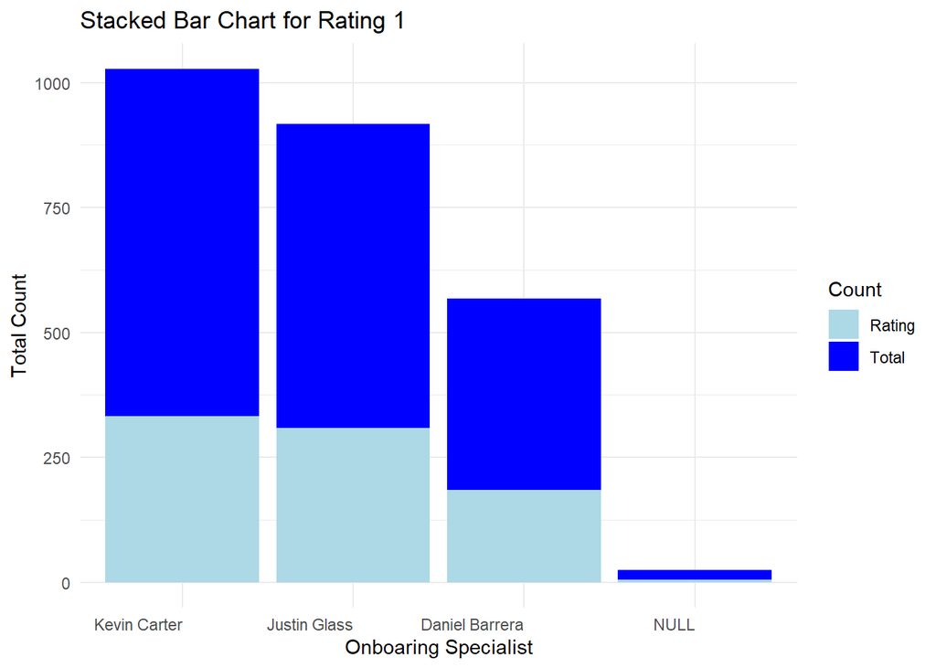

```r
# Make Vis
onboard_df |> filter(rating == 1) |>
   ggplot(aes(x = reorder(onboard, -total_count))) +
  geom_bar(aes(y = total_count, fill = "Total"),
           stat = "identity",
           position = "stack") +
  geom_bar(aes(y = rating_count, fill = "Rating"),
           stat = "identity",
           position = "stack") +
  scale_fill_manual(values = c("Total" = "blue",
                               "Rating" = "lightblue")) +
  labs(x = "Onboaring Specialist", y = "Total Count",
       title = "Stacked Bar Chart for Rating 1",
       fill = "Count") +
  theme_minimal() +
  theme(legend.position = "right",
        axis.text.x = element_text(angle = 0, hjust = 1))
```

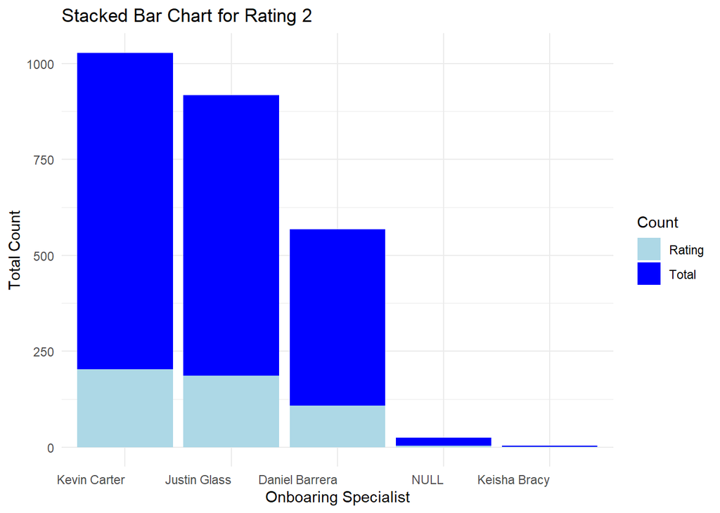

```r
# Make Vis
onboard_df |> filter(rating == 2) |>
   ggplot(aes(x = reorder(onboard, -total_count))) +
  geom_bar(aes(y = total_count, fill = "Total"),
           stat = "identity",
           position = "stack") +
  geom_bar(aes(y = rating_count, fill = "Rating"),
           stat = "identity",
           position = "stack") +
  scale_fill_manual(values = c("Total" = "blue",
                               "Rating" = "lightblue")) +
  labs(x = "Onboaring Specialist", y = "Total Count",
       title = "Stacked Bar Chart for Rating 2",
       fill = "Count") +
  theme_minimal() +
  theme(legend.position = "right",
        axis.text.x = element_text(angle = 0, hjust = 1))
```

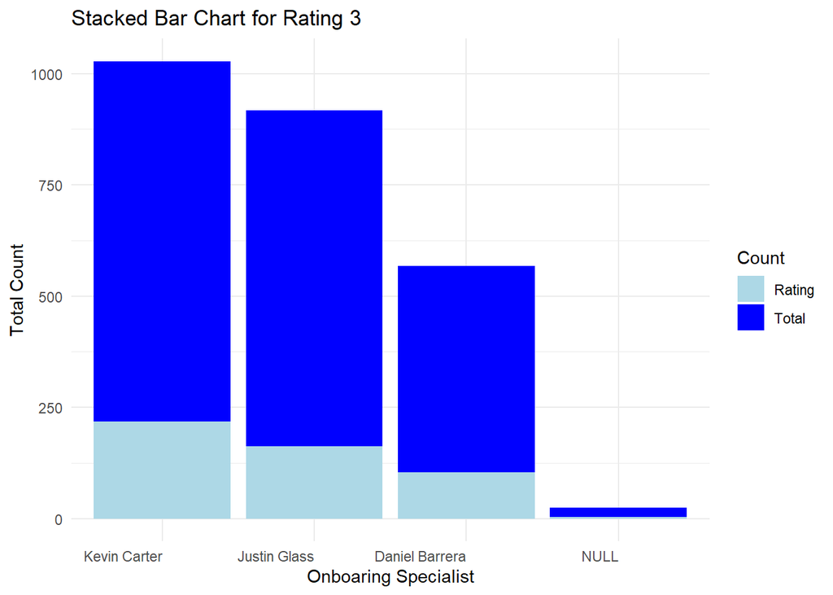

```r
# Make Vis
onboard_df |> filter(rating == 3) |>
   ggplot(aes(x = reorder(onboard, -total_count))) +
  geom_bar(aes(y = total_count, fill = "Total"),
           stat = "identity",
           position = "stack") +
  geom_bar(aes(y = rating_count, fill = "Rating"),
           stat = "identity",
           position = "stack") +
  scale_fill_manual(values = c("Total" = "blue",
                               "Rating" = "lightblue")) +
  labs(x = "Onboaring Specialist", y = "Total Count",
       title = "Stacked Bar Chart for Rating 3",
       fill = "Count") +
  theme_minimal() +
  theme(legend.position = "right",
        axis.text.x = element_text(angle = 0, hjust = 1))
```

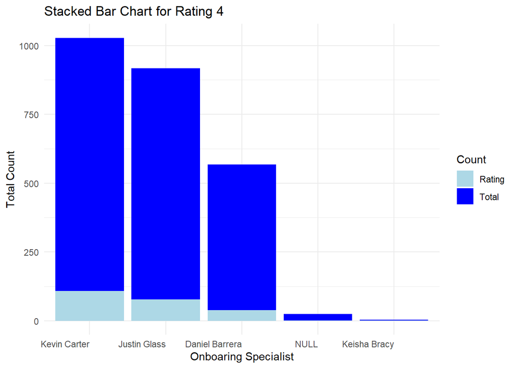

```r
# Make Vis
onboard_df |> filter(rating == 4) |>
   ggplot(aes(x = reorder(onboard, -total_count))) +
  geom_bar(aes(y = total_count, fill = "Total"),
           stat = "identity",
           position = "stack") +
  geom_bar(aes(y = rating_count, fill = "Rating"),
           stat = "identity",
           position = "stack") +
  scale_fill_manual(values = c("Total" = "blue",
                               "Rating" = "lightblue")) +
  labs(x = "Onboaring Specialist", y = "Total Count",
       title = "Stacked Bar Chart for Rating 4",
       fill = "Count") +
  theme_minimal() +
  theme(legend.position = "right",
        axis.text.x = element_text(angle = 0, hjust = 1))
```

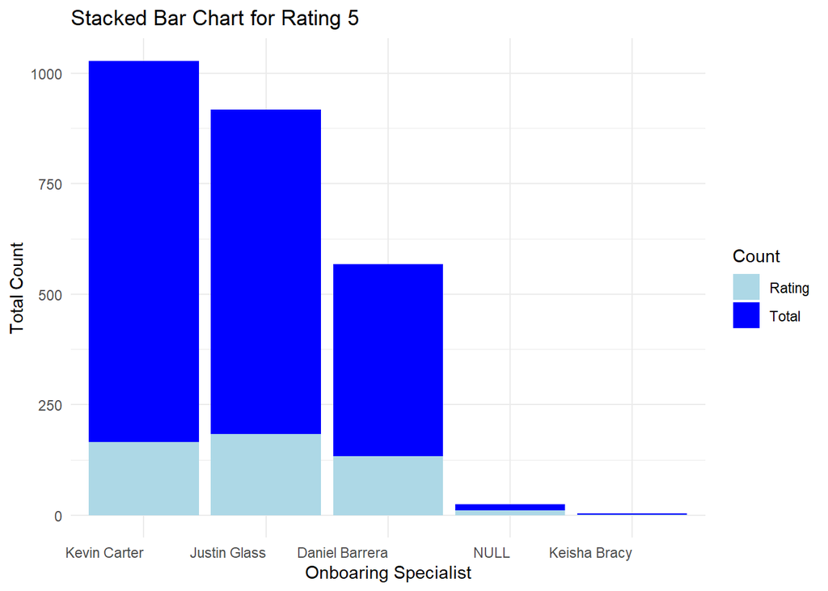

```r
# Make Vis
onboard_df |> filter(rating == 5) |>
   ggplot(aes(x = reorder(onboard, -total_count))) +
  geom_bar(aes(y = total_count, fill = "Total"),
           stat = "identity",
           position = "stack") +
  geom_bar(aes(y = rating_count, fill = "Rating"),
           stat = "identity",
           position = "stack") +
  scale_fill_manual(values = c("Total" = "blue",
                               "Rating" = "lightblue")) +
  labs(x = "Onboaring Specialist", y = "Total Count",
       title = "Stacked Bar Chart for Rating 5",
       fill = "Count") +
  theme_minimal() +
  theme(legend.position = "right",
        axis.text.x = element_text(angle = 0, hjust = 1))
```

NOTE: There is a single occurrence where Kevin Carter has a rating of 0. Keisha Bracy barely shows up because her total ratings are 3. She has a 2, 4 and 5 rating.